# Intro to Shiny Part 2

2021-03-04

- Learning Goals
- Group project
- Load the Libraries
- Running A Shiny App from Script
- Practice
- Automatically Stopping an App
- Adding Numeric Input
- ui Layout with `shinydashboard`
- Practice
- That’s it, let’s take a break!

## Learning Goals

*At the end of this exercise, you will be able to:*  
1. Run a shiny app from a stand alone script.  
2. Configure a shiny app to automatically stop when closed.  
3. Add a new input to the ui.  
3. Use `shinydashboard` to improve ui aesthetics.

## Group project

We will meet in our groups today to compare the data sets that we found. You should try to pick the data set that you think will be most appropriate; i.e. does it have a mix of variables, does it have a story to tell? Once you have a data set, think about the kinds of questions you might ask. Remember, in the end you will need to deliver a 5-6 minute presentation of your work. If you need help, please ask!

## Load the Libraries

```r
library("tidyverse")
library("shiny")
library("naniar")
library("shinydashboard")
library("palmerpenguins")
```

```r
if (!require("tidyverse")) install.packages('tidyverse')
#Very helpful code to add to standalone version of app. This is helpful because instead of only using library, do require
#require(janitor)
#BUT if janitor isn't installed, require will install and library call that app for people.
```

## Running A Shiny App from Script

Copy and pasting code into the console is okay for tiny example apps, but it’s not feasible for large apps, especially because advanced shiny apps can be hundreds of line of code or more. The best way to work on apps is from a stand alone script. R Studio should automatically recognize the shiny app from the basic app building blocks/skeleton. All we have to do to run our app is click the “Run App” button at the top right of the editor window.

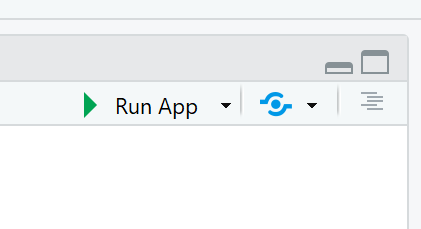

## Practice

1. Open and save your finished homerange app from question 3 in part 1 as a stand alone `.R` script. What packages do you need to make sure to load at the top? Run the app by clicking the Run App button. Set the run method in the Run App drop down to “Run External”.

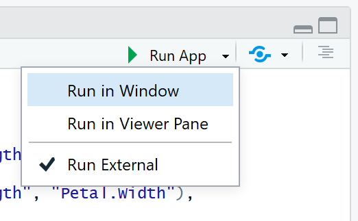

## Automatically Stopping an App

When we are building an app and frequently testing it, it can be cumbersome to always make sure to stop our app by clicking the stop button. When we close the window we want the app to also stop. This can be done with a couple lines of code that tell R to stop the app in the current session when we close the window. Add the code to our current app at the end of the server function (but inside the function) and try re-running it. Your server function should look like this:

```r
ui <- fluidPage(

  titlePanel("Log 10 Homerange by Taxon"),
  sidebarLayout(
  sidebarPanel(
  selectInput("taxon", " Select Taxon of Interest:", choices=unique(homerange$taxon)),
      hr(),
      helpText("Reference: Tamburello N, Cote IM, Dulvy NK (2015) Energy and the scaling of animal space use. The American Naturalist 186(2):196-211.")
    ),
    mainPanel(
      plotOutput("taxonPlot")
    )
    )
    )
server <- function(input, output, session) {
  session$onSessionEnded(stopApp)
  output$taxonPlot <- renderPlot({
    homerange %>%
    filter(taxon == input$taxon) %>%
    ggplot(aes(x=log10.hra)) +
    geom_density(color="black", fill="steelblue", alpha=0.6)
  })
}
shinyApp(ui, server)
```

Have session present in server <- function, and also have line “session$onSessionEnded(stopApp)”, which will stop the app. Very handy single line of code that you can add to your app. BUT make sure the session part is present, or else the whole app won’t work.

Sliderinput to userinput to allow users to control font size. Font size is part of a theme. Make sure you call it in theme!

## Adding Numeric Input

Let’s try adding a new numeric input so the user can change the size of the font on the plot with a slider. We can do this with the `sliderInput()` function. The `sliderInput()` function takes a label that the server function will use to access the value, the label that the ui will display to the user, a minimum and maximum value, a starting value, and a step size. Edit the script to include the slider input in the ui and for the server to access the input value.

```r
ui <- fluidPage(
    selectInput("x", "Select X Variable", choices = c("bill_length_mm", "bill_depth_mm", "flipper_length_mm", "body_mass_g"),
              selected = "bill_length_mm"),
    selectInput("y", "Select Y Variable", choices = c("bill_length_mm", "bill_depth_mm", "flipper_length_mm", "body_mass_g"),
              selected = "bill_depth_mm"),
    sliderInput("fontsize", "Select the Font Size", min = 10, max = 24, value = 18, step = 1),
    plotOutput("plot", width = "500px", height = "400px")
)

server <- function(input, output, session) {
  session$onSessionEnded(stopApp)
  output$plot <- renderPlot({
  ggplot(penguins, aes_string(x = input$x, y = input$y, color="species")) + geom_point() + theme_light(base_size = input$fontsize)
  })
}

shinyApp(ui, server)
```

## ui Layout with `shinydashboard`

We now have a functional app, but the layout doesn’t look very nice. We can change that with many different methods, but shiny dashboards are simple to use and offer a lot of functionality for making apps look professional quickly. First we need to install the `shinydashboard` package.

```r
#install.packages("shinydashboard")
library(shinydashboard)
```

When working with any package on shiny ui appearance, it’s important to know how the ui is laid out. The ui is laid out in a bootstrap grid pattern with 12 columns that can be subdivided into rows. The grid is contained in the `fluidPage()` of our current app.

We won’t use `fluidPage()` with `shinydashboard` but rather `dashboardPage()`. A shiny dashboard contains a minimum of a header, a sidebar, and a body. The `dashboardPage()` still contains the bootstrap grid.

```r
library(shinydashboard)

ui <- dashboardPage(
  dashboardHeader(),
  dashboardSidebar(),
  dashboardBody()
)

server <- function(input, output) { }

shinyApp(ui, server)
```

Let’s edit the title of our dashboard.

```r
ui <- dashboardPage(
  dashboardHeader(title = "Penguins"),
  dashboardSidebar(),
  dashboardBody()
)

server <- function(input, output) { }

shinyApp(ui, server)
```

Let’s add our ui and server elements to make a functional dashboard. We will put our ui elements in the `dashboardBody()`. Edit your app script to use the dashboard format. We won’t do anything with the sidebar in this tutorial, but see the [R Studio tutorial](https://rstudio.github.io/shinydashboard/get_started.html) for more information.

```r
ui <- dashboardPage(
  dashboardHeader(title = "Penguins"),
  dashboardSidebar(),
  dashboardBody(
  selectInput("x", "Select X Variable", choices = c("bill_length_mm", "bill_depth_mm", "flipper_length_mm", "body_mass_g"), selected = "bill_length_mm"),
  selectInput("y", "Select Y Variable", choices = c("bill_length_mm", "bill_depth_mm", "flipper_length_mm", "body_mass_g"), selected = "bill_depth_mm"),
  plotOutput("plot", width = "500px", height = "400px"))
)

server <- function(input, output, session) {
  output$plot <- renderPlot({
  ggplot(penguins, aes_string(x = input$x, y = input$y, color="species")) + geom_point() + theme_light()
  })
  session$onSessionEnded(stopApp)
  }

shinyApp(ui, server)
```

Boxes are a nice way to group inputs and display outputs in `shinydashboard`. We can display our inputs and outputs in a box with `box()`. Boxes need to be contained in a `fluidRow()`. We will use just one row. Edit your app to contain boxes in the ui.

```r
ui <- dashboardPage(
  dashboardHeader(title = "Penguins"),
  dashboardSidebar(disable = T),
  dashboardBody(
  fluidRow(
  box(
  selectInput("x", "Select X Variable", choices = c("bill_length_mm", "bill_depth_mm", "flipper_length_mm", "body_mass_g"), selected = "bill_length_mm"),
  selectInput("y", "Select Y Variable", choices = c("bill_length_mm", "bill_depth_mm", "flipper_length_mm", "body_mass_g"), selected = "bill_depth_mm"),
   sliderInput("pointsize", "Select the Point Size", min = 1, max = 5, value = 2, step = 0.5)
  ), # close the first box
  box(
  plotOutput("plot", width = "500px", height = "500px")
  ) # close the second box
  ) # close the row
  ) # close the dashboard body
) # close the ui

server <- function(input, output, session) {
  output$plot <- renderPlot({
  ggplot(penguins, aes_string(x = input$x, y = input$y, color="species")) + geom_point(size=input$pointsize, alpha=0.8) + theme_light(base_size = 18)
  })
  session$onSessionEnded(stopApp)
  }

shinyApp(ui, server)
```

```r
ui <- dashboardPage(
  dashboardHeader(title = "Penguins"),
  dashboardSidebar(disable = T),
  dashboardBody(
  fluidRow(
  box(title = "Plot Options", width = 3,
  selectInput("x", "Select X Variable", choices = c("bill_length_mm", "bill_depth_mm", "flipper_length_mm", "body_mass_g"), selected = "bill_length_mm"),
  selectInput("y", "Select Y Variable", choices = c("bill_length_mm", "bill_depth_mm", "flipper_length_mm", "body_mass_g"), selected = "bill_depth_mm"),
   sliderInput("pointsize", "Select the Point Size", min = 1, max = 5, value = 2, step = 0.5)
  ), # close the first box
  box(title = "Plot of Penguins Data", width = 7,
  plotOutput("plot", width = "600px", height = "500px")
  ) # close the second box
  ) # close the row
  ) # close the dashboard body
) # close the ui

server <- function(input, output, session) {
  output$plot <- renderPlot({
  ggplot(penguins, aes_string(x = input$x, y = input$y, color="species")) + geom_point(size=input$pointsize, alpha=0.8) + theme_light(base_size = 18)
  })
  session$onSessionEnded(stopApp)
  }

shinyApp(ui, server)
```

Whew! We made it! We created a nice looking app with `shinydashboard`. And now we can easily see how even a basic shiny app can become messy and why it’s always helpful to include lots of annotations.

## Practice

We will use data from a study on vertebrate community composition and impacts from defaunation in Gabon, Africa.

Reference: Koerner SE, Poulsen JR, Blanchard EJ, Okouyi J, Clark CJ. Vertebrate community composition and diversity declines along a defaunation gradient radiating from rural villages in Gabon. *Journal of Applied Ecology*. 2016.

1. Load `IvindoData_DryadVersion.csv` and use the function(s) of your choice to get an idea of the overall structure, including its dimensions, column names, variable classes, etc. As part of this, determine if NA’s are present and how they are treated.

```r
gabon <- readr::read_csv("data/IvindoData_DryadVersion.csv")
```

```r
names(gabon)
```

[output not shown]

```r
glimpse(gabon)
```

[output not shown]

2. Build an app that re-creates the plots shown on page 810 of this paper. It compares the relative abundance % to the distance from villages in rural Gabon. Use shiny dashboard and add aesthetics to the plot.

```r
ui <- dashboardPage(
  dashboardHeader(title = "Relative Abundance"),
  dashboardSidebar(disable = T),
  dashboardBody(
  fluidRow(
  box(title = "Plot Options", width = 3,
  selectInput("x", "Select RA Taxon", choices = c("RA_Apes", "RA_Birds", "RA_Elephant", "RA_Monkeys", "RA_Rodent", "RA_Ungulate"),
              selected = "RA_Apes"),
      hr(),
      helpText("Reference: Koerner SE, Poulsen JR, Blanchard EJ, Okouyi J, Clark CJ. Vertebrate community composition and diversity declines along a defaunation gradient radiating from rural villages in Gabon. Journal of Applied Ecology. 2016.")
  ), # close the first box
  box(title = "Relative Abundance %", width = 6,
  plotOutput("plot", width = "600px", height = "500px")
  ) # close the second box
  ) # close the row
  ) # close the dashboard body
) # close the ui

server <- function(input, output, session) {

  output$plot <- renderPlot({
  gabon %>%
  ggplot(aes_string(x = "Distance", y = input$x)) +
  geom_point(size=4)+
  geom_smooth(method=lm, se=T)+
  scale_x_continuous(breaks=seq(0, 30, by = 5))+ theme_light(base_size = 18)
  })

  # stop the app when we close it
  session$onSessionEnded(stopApp)
  }

shinyApp(ui, server)
```

```
Listening on http://127.0.0.1:3026
```

## That’s it, let’s take a break!

–>[Home](https://jmledford3115.github.io/datascibiol/)